# PART A

### Domain : Electronics & Telecommunication

### Context

A communications equipment manufacturing company has a product that is responsible for emitting informative signals. The company wants to build a machine learning model that can help the company predict the equipment’s signal quality using various parameters.

### Objective

To build a classifier that can use the given parameters to determine the signal strength or quality.

## Data Dictionary

The data set contains information on various signal tests performed:

- Parameters: Various measurable signal parameters.
- Signal_Quality: Final signal strength or quality

### Q1 A - Read the ‘Signals.csv’ as DatFrame and import required libraries.

#### Import necessary libraries

```python
import pandas as pd
import sys
import numpy as np
import seaborn as sns
import matplotlib.pyplot as plt

from sklearn.model_selection import train_test_split
from scipy.stats import zscore
import warnings
from sklearn.metrics import confusion_matrix
from sklearn.metrics import classification_report
```

```python
# Read csv file
df = pd.read_csv('NN Project Data - Signal.csv')
df.head()
```

|  | Parameter 1 | Parameter 2 | Parameter 3 | Parameter 4 | Parameter 5 | Parameter 6 | Parameter 7 | Parameter 8 | Parameter 9 | Parameter 10 | Parameter 11 | Signal_Strength |
| --- | --- | --- | --- | --- | --- | --- | --- | --- | --- | --- | --- | --- |
| 0 | 7.4 | 0.70 | 0.00 | 1.9 | 0.076 | 11.0 | 34.0 | 0.9978 | 3.51 | 0.56 | 9.4 | 5 |
| 1 | 7.8 | 0.88 | 0.00 | 2.6 | 0.098 | 25.0 | 67.0 | 0.9968 | 3.20 | 0.68 | 9.8 | 5 |
| 2 | 7.8 | 0.76 | 0.04 | 2.3 | 0.092 | 15.0 | 54.0 | 0.9970 | 3.26 | 0.65 | 9.8 | 5 |
| 3 | 11.2 | 0.28 | 0.56 | 1.9 | 0.075 | 17.0 | 60.0 | 0.9980 | 3.16 | 0.58 | 9.8 | 6 |
| 4 | 7.4 | 0.70 | 0.00 | 1.9 | 0.076 | 11.0 | 34.0 | 0.9978 | 3.51 | 0.56 | 9.4 | 5 |

```python
df.info()
```

```
<class 'pandas.core.frame.DataFrame'>
RangeIndex: 1599 entries, 0 to 1598
Data columns (total 12 columns):
 #   Column           Non-Null Count  Dtype
---  ------           --------------  -----
 0   Parameter 1      1599 non-null   float64
 1   Parameter 2      1599 non-null   float64
 2   Parameter 3      1599 non-null   float64
 3   Parameter 4      1599 non-null   float64
 4   Parameter 5      1599 non-null   float64
 5   Parameter 6      1599 non-null   float64
 6   Parameter 7      1599 non-null   float64
 7   Parameter 8      1599 non-null   float64
 8   Parameter 9      1599 non-null   float64
 9   Parameter 10     1599 non-null   float64
 10  Parameter 11     1599 non-null   float64
 11  Signal_Strength  1599 non-null   int64
dtypes: float64(11), int64(1)
memory usage: 150.0 KB
```

### Q1 B - Check for missing values and print percentage for each attribute.

```python
# Check for missing values
df.isnull().sum()*100/len(df)
```

```
Parameter 1        0.0
Parameter 2        0.0
Parameter 3        0.0
Parameter 4        0.0
Parameter 5        0.0
Parameter 6        0.0
Parameter 7        0.0
Parameter 8        0.0
Parameter 9        0.0
Parameter 10       0.0
Parameter 11       0.0
Signal_Strength    0.0
dtype: float64
```

```python
# Check if any column has na values
df.columns[df.isna().any()].tolist()
```

```
[]
```

```python
df.shape
```

```
(1599, 12)
```

```python
df.describe()
```

|  | Parameter 1 | Parameter 2 | Parameter 3 | Parameter 4 | Parameter 5 | Parameter 6 | Parameter 7 | Parameter 8 | Parameter 9 | Parameter 10 | Parameter 11 | Signal_Strength |
| --- | --- | --- | --- | --- | --- | --- | --- | --- | --- | --- | --- | --- |
| count | 1599.000000 | 1599.000000 | 1599.000000 | 1599.000000 | 1599.000000 | 1599.000000 | 1599.000000 | 1599.000000 | 1599.000000 | 1599.000000 | 1599.000000 | 1599.000000 |
| mean | 8.319637 | 0.527821 | 0.270976 | 2.538806 | 0.087467 | 15.874922 | 46.467792 | 0.996747 | 3.311113 | 0.658149 | 10.422983 | 5.636023 |
| std | 1.741096 | 0.179060 | 0.194801 | 1.409928 | 0.047065 | 10.460157 | 32.895324 | 0.001887 | 0.154386 | 0.169507 | 1.065668 | 0.807569 |
| min | 4.600000 | 0.120000 | 0.000000 | 0.900000 | 0.012000 | 1.000000 | 6.000000 | 0.990070 | 2.740000 | 0.330000 | 8.400000 | 3.000000 |
| 25% | 7.100000 | 0.390000 | 0.090000 | 1.900000 | 0.070000 | 7.000000 | 22.000000 | 0.995600 | 3.210000 | 0.550000 | 9.500000 | 5.000000 |
| 50% | 7.900000 | 0.520000 | 0.260000 | 2.200000 | 0.079000 | 14.000000 | 38.000000 | 0.996750 | 3.310000 | 0.620000 | 10.200000 | 6.000000 |
| 75% | 9.200000 | 0.640000 | 0.420000 | 2.600000 | 0.090000 | 21.000000 | 62.000000 | 0.997835 | 3.400000 | 0.730000 | 11.100000 | 6.000000 |
| max | 15.900000 | 1.580000 | 1.000000 | 15.500000 | 0.611000 | 72.000000 | 289.000000 | 1.003690 | 4.010000 | 2.000000 | 14.900000 | 8.000000 |

- There are no missing values
- Data set of 1599 rows/records and 12 columns
- All attributes except target variable are of type float .Signal strength is of type int
- There are no null values present in the data

### Q1C. Check for presence of duplicate records in the dataset and impute with appropriate method.

```python
# find duplicate rows in the dataframe
df[df.duplicated()]
```

|  | Parameter 1 | Parameter 2 | Parameter 3 | Parameter 4 | Parameter 5 | Parameter 6 | Parameter 7 | Parameter 8 | Parameter 9 | Parameter 10 | Parameter 11 | Signal_Strength |
| --- | --- | --- | --- | --- | --- | --- | --- | --- | --- | --- | --- | --- |
| 4 | 7.4 | 0.700 | 0.00 | 1.90 | 0.076 | 11.0 | 34.0 | 0.99780 | 3.51 | 0.56 | 9.4 | 5 |
| 11 | 7.5 | 0.500 | 0.36 | 6.10 | 0.071 | 17.0 | 102.0 | 0.99780 | 3.35 | 0.80 | 10.5 | 5 |
| 27 | 7.9 | 0.430 | 0.21 | 1.60 | 0.106 | 10.0 | 37.0 | 0.99660 | 3.17 | 0.91 | 9.5 | 5 |
| 40 | 7.3 | 0.450 | 0.36 | 5.90 | 0.074 | 12.0 | 87.0 | 0.99780 | 3.33 | 0.83 | 10.5 | 5 |
| 65 | 7.2 | 0.725 | 0.05 | 4.65 | 0.086 | 4.0 | 11.0 | 0.99620 | 3.41 | 0.39 | 10.9 | 5 |
| ... | ... | ... | ... | ... | ... | ... | ... | ... | ... | ... | ... | ... |
| 1563 | 7.2 | 0.695 | 0.13 | 2.00 | 0.076 | 12.0 | 20.0 | 0.99546 | 3.29 | 0.54 | 10.1 | 5 |
| 1564 | 7.2 | 0.695 | 0.13 | 2.00 | 0.076 | 12.0 | 20.0 | 0.99546 | 3.29 | 0.54 | 10.1 | 5 |
| 1567 | 7.2 | 0.695 | 0.13 | 2.00 | 0.076 | 12.0 | 20.0 | 0.99546 | 3.29 | 0.54 | 10.1 | 5 |
| 1581 | 6.2 | 0.560 | 0.09 | 1.70 | 0.053 | 24.0 | 32.0 | 0.99402 | 3.54 | 0.60 | 11.3 | 5 |
| 1596 | 6.3 | 0.510 | 0.13 | 2.30 | 0.076 | 29.0 | 40.0 | 0.99574 | 3.42 | 0.75 | 11.0 | 6 |

240 rows × 12 columns

- There are duplicates present

```python
df.duplicated().value_counts()
```

```
False    1359
True      240
Name: count, dtype: int64
```

```python
#dropping the duplicates
df.drop_duplicates(keep=False,inplace=True)
df[df.duplicated()]
```

|  | Parameter 1 | Parameter 2 | Parameter 3 | Parameter 4 | Parameter 5 | Parameter 6 | Parameter 7 | Parameter 8 | Parameter 9 | Parameter 10 | Parameter 11 | Signal_Strength |
| --- | --- | --- | --- | --- | --- | --- | --- | --- | --- | --- | --- | --- |

```python
print(df.shape)
```

```
(1139, 12)
```

### Q1D.Visualise distribution of the target variable

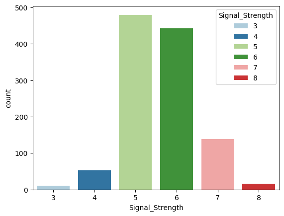

```python
# target variable is Signal_Strength
sns.countplot(data=df, x= 'Signal_Strength',hue = 'Signal_Strength', palette="Paired")
```

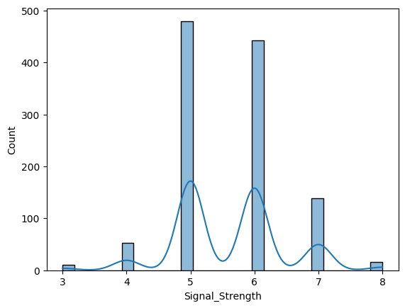

```python
sns.histplot(df['Signal_Strength'], kde=True)
```

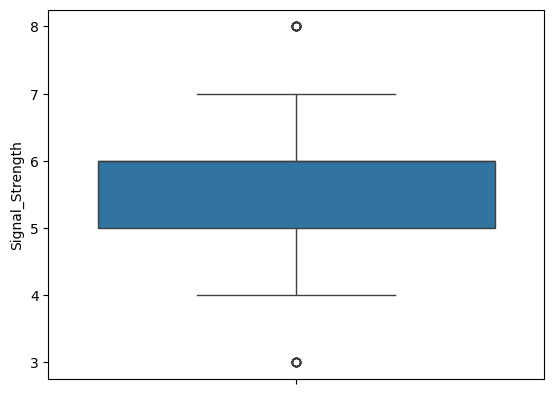

```python
sns.boxplot(df['Signal_Strength'])
```

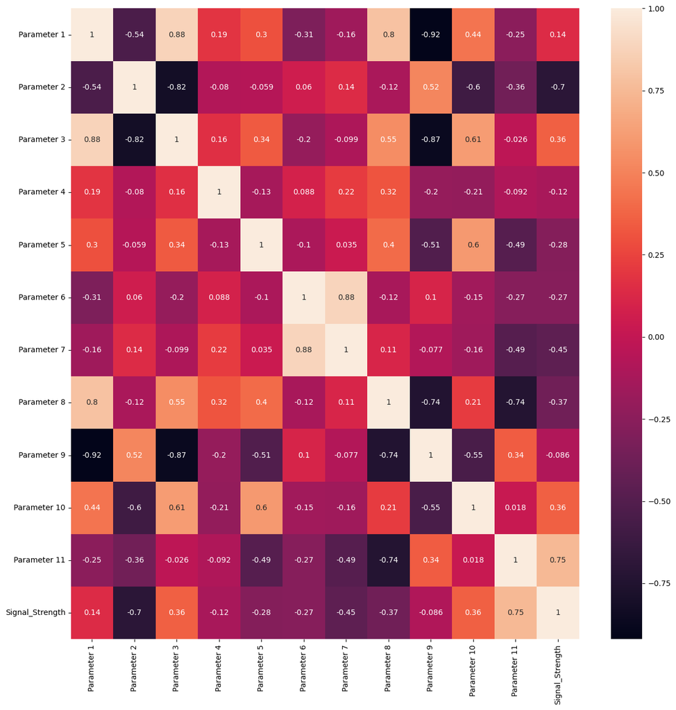

```python
# Correlation matrix
corr=df.corr()
# Heat Map
plt.figure(figsize=(15,15))
sns.heatmap(corr.corr(), annot=True )  # heatmap
plt.show()
```

### Q1E.Share insights from the initial data analysis (at least 2).

##### Highly correlated variables can significantly impact most machine learning algorithms. However, neural networks are inherently robust to multicollinearity due to their ability to learn non-linear relationships and manage feature interactions during training. Since we are solving this problem using neural networks, we will proceed without applying techniques to reduce multicollinearity.

### Q2 A.Split the data into X & Y.

```python
# Split X & y variables
X = df.drop(['Signal_Strength'],axis=1)
y = df[['Signal_Strength']]
```

### Q2 B.Split the data into train & test with 70:30 proportion.

```python
X_train, X_test, y_train, y_test = train_test_split(X,y, test_size = 0.30, random_state = 0,stratify = y)
```

### Q2 C.Print shape of all the 4 variables and verify if train and test data is in sync.

```python
# Assuming you have already split your data into train and test sets for features and target
print("Shapes of Train and Test Datasets:")

# Replace `X_train`, `X_test`, `y_train`, and `y_test` with your variable names
print(f"X_train shape: {X_train.shape}")
print(f"X_test shape: {X_test.shape}")
print(f"y_train shape: {y_train.shape}")
print(f"y_test shape: {y_test.shape}")
```

```
Shapes of Train and Test Datasets:
X_train shape: (797, 11)
X_test shape: (342, 11)
y_train shape: (797, 1)
y_test shape: (342, 1)
```

```python
# Check sync by verifying that the number of features matches
if X_train.shape[1] == X_test.shape[1]:
    print("Feature columns in train and test are in sync.")
else:
    print("Feature columns in train and test are NOT in sync!")

# Check sync by verifying target data length
if y_train.shape[0] + y_test.shape[0] == X_train.shape[0] + X_test.shape[0]:
    print("Target data is in sync between train and test.")
else:
    print("Target data is NOT in sync!")
```

```
Feature columns in train and test are in sync.
Target data is in sync between train and test.
```

### Q2 D.Normalise the train and test data with appropriate method.

```python
#Applying Standard Scaler
from sklearn.preprocessing import StandardScaler
X_train = pd.DataFrame(StandardScaler().fit_transform(X_train))
X_test = pd.DataFrame(StandardScaler().fit_transform(X_test))
print(pd.DataFrame(X_train).isna().sum().sum())
print(pd.DataFrame(X_test).isna().sum().sum())
```

```
0
0
```

```python
print("X_train.shape",X_train.shape)
print("X_test.shape",X_test.shape)
print("y_train.shape",y_train.shape)
print("y_test.shape",y_test.shape)
```

```
X_train.shape (797, 11)
X_test.shape (342, 11)
y_train.shape (797, 1)
y_test.shape (342, 1)
```

```python
# checking data after scaling
X_train.describe()
```

|  | 0 | 1 | 2 | 3 | 4 | 5 | 6 | 7 | 8 | 9 | 10 |
| --- | --- | --- | --- | --- | --- | --- | --- | --- | --- | --- | --- |
| count | 7.970000e+02 | 7.970000e+02 | 7.970000e+02 | 7.970000e+02 | 7.970000e+02 | 7.970000e+02 | 7.970000e+02 | 7.970000e+02 | 7.970000e+02 | 7.970000e+02 | 7.970000e+02 |
| mean | -7.132173e-17 | -3.610663e-16 | 1.092114e-16 | 8.469455e-17 | 2.652277e-16 | 6.686412e-17 | 9.806738e-17 | -1.237432e-14 | -4.725065e-16 | -2.942021e-16 | 4.479896e-16 |
| std | 1.000628e+00 | 1.000628e+00 | 1.000628e+00 | 1.000628e+00 | 1.000628e+00 | 1.000628e+00 | 1.000628e+00 | 1.000628e+00 | 1.000628e+00 | 1.000628e+00 | 1.000628e+00 |
| min | -2.108003e+00 | -2.009461e+00 | -1.355509e+00 | -1.063226e+00 | -1.153680e+00 | -1.425794e+00 | -1.188369e+00 | -3.449246e+00 | -3.723236e+00 | -2.018944e+00 | -1.847140e+00 |
| 25% | -7.153362e-01 | -7.631473e-01 | -8.982758e-01 | -4.945617e-01 | -3.882459e-01 | -8.469057e-01 | -7.590123e-01 | -5.978422e-01 | -6.207962e-01 | -6.392511e-01 | -8.648495e-01 |
| 50% | -1.930862e-01 | -5.870887e-02 | -8.541652e-02 | -2.508484e-01 | -1.695506e-01 | -1.715359e-01 | -2.683190e-01 | -6.041538e-03 | -3.908867e-02 | -2.629711e-01 | -2.397556e-01 |
| 75% | 5.032472e-01 | 6.457295e-01 | 7.782465e-01 | 7.410271e-02 | 7.101424e-02 | 5.038339e-01 | 4.370525e-01 | 6.395592e-01 | 6.072530e-01 | 4.268756e-01 | 6.532356e-01 |
| max | 4.449136e+00 | 4.330484e+00 | 3.724861e+00 | 1.055377e+01 | 1.144317e+01 | 4.845497e+00 | 7.460100e+00 | 3.544763e+00 | 4.485303e+00 | 8.454182e+00 | 3.957303e+00 |

```python
y_train.describe()
```

|  | Signal_Strength |
| --- | --- |
| count | 797.000000 |
| mean | 5.608532 |
| std | 0.843138 |
| min | 3.000000 |
| 25% | 5.000000 |
| 50% | 6.000000 |
| 75% | 6.000000 |
| max | 8.000000 |

```python
X_test.describe()
```

|  | 0 | 1 | 2 | 3 | 4 | 5 | 6 | 7 | 8 | 9 | 10 |
| --- | --- | --- | --- | --- | --- | --- | --- | --- | --- | --- | --- |
| count | 3.420000e+02 | 3.420000e+02 | 342.000000 | 3.420000e+02 | 3.420000e+02 | 3.420000e+02 | 3.420000e+02 | 3.420000e+02 | 3.420000e+02 | 3.420000e+02 | 3.420000e+02 |
| mean | -6.232831e-17 | -1.480297e-16 | 0.000000 | -1.246566e-16 | 1.636118e-16 | -8.310441e-17 | 8.310441e-17 | -1.684423e-14 | -1.462118e-15 | -1.791939e-16 | 9.115515e-16 |
| std | 1.001465e+00 | 1.001465e+00 | 1.001465 | 1.001465e+00 | 1.001465e+00 | 1.001465e+00 | 1.001465e+00 | 1.001465e+00 | 1.001465e+00 | 1.001465e+00 | 1.001465e+00 |
| min | -1.984093e+00 | -1.740774e+00 | -1.488903 | -9.571917e-01 | -8.562986e-01 | -1.273161e+00 | -1.208137e+00 | -3.125055e+00 | -2.728587e+00 | -1.410610e+00 | -1.603427e+00 |
| 25% | -7.064213e-01 | -7.226556e-01 | -0.870686 | -4.247142e-01 | -3.844313e-01 | -7.939389e-01 | -7.458116e-01 | -6.039210e-01 | -6.607485e-01 | -5.943177e-01 | -8.398108e-01 |
| 50% | -2.418135e-01 | -6.087871e-02 | -0.046396 | -1.965096e-01 | -2.167429e-01 | -2.188727e-01 | -2.290951e-01 | 1.718696e-02 | 5.007102e-02 | -2.626992e-01 | -2.670984e-01 |
| 75% | 6.293263e-01 | 5.499923e-01 | 0.816531 | 1.077633e-01 | -2.955585e-02 | 5.478823e-01 | 4.507950e-01 | 6.580575e-01 | 5.670307e-01 | 2.729923e-01 | 5.919703e-01 |
| max | 4.171961e+00 | 5.335148e+00 | 2.581026 | 8.323131e+00 | 8.066283e+00 | 5.340101e+00 | 6.189068e+00 | 3.622436e+00 | 4.638088e+00 | 6.650272e+00 | 3.455533e+00 |

```python
y_test.describe()
```

|  | Signal_Strength |
| --- | --- |
| count | 342.000000 |
| mean | 5.608187 |
| std | 0.845025 |
| min | 3.000000 |
| 25% | 5.000000 |
| 50% | 6.000000 |
| 75% | 6.000000 |
| max | 8.000000 |

### Q2 E.Transform Labels into format acceptable by Neural Network

```python
#Only labeled column in the dataset is signal strength
labeled_columns=["Signal_Strength"]
y_train = pd.get_dummies(y_train, columns=labeled_columns, drop_first=True).astype(int)
y_test = pd.get_dummies(y_test, columns=labeled_columns, drop_first=True).astype(int)

y_train.head()
```

|  | Signal_Strength_4 | Signal_Strength_5 | Signal_Strength_6 | Signal_Strength_7 | Signal_Strength_8 |
| --- | --- | --- | --- | --- | --- |
| 1364 | 0 | 0 | 1 | 0 | 0 |
| 820 | 0 | 1 | 0 | 0 | 0 |
| 1540 | 0 | 0 | 1 | 0 | 0 |
| 1473 | 0 | 1 | 0 | 0 | 0 |
| 216 | 0 | 1 | 0 | 0 | 0 |

### Q3 A. Design a Neural Network to train a classifier.

- Start with building a basic network & check accuracy on this as a sanity test

```python
import tensorflow as tf
from tensorflow.keras.models import Sequential
from tensorflow.keras.layers import Dense, Dropout, Input

# Define the model
model = Sequential()
# Input layer (adjust input_dim to match the number of features in your dataset)
model.add(Input(shape = (X_train.shape[1],)))

# Hidden layer
model.add(Dense(units=1, activation='relu'))

# Output layer (adjust units to match the number of classes; use softmax for multi-class)
model.add(Dense(units=y_train.shape[1], activation='softmax'))

# Compile the model
model.compile(optimizer='adam',
              loss='categorical_crossentropy',  # Use binary_crossentropy for binary classification
              metrics=['accuracy'])
```

### Q3 B.Train the classifier using previously designed Architecture

```python
# Train the model
history = model.fit(X_train, y_train, epochs=50, batch_size=32, validation_data=(X_test, y_test))

# Evaluate the model
loss, accuracy = model.evaluate(X_test, y_test)
print(f"Test Loss: {loss}")
print(f"Test Accuracy: {accuracy}")
```

```
25/25 ━━━━━━━━━━━━━━━━━━━━ 1s 6ms/step - accuracy: 0.3099 - loss: 1.5187 - val_accuracy: 0.3567 - val_loss: 1.4979
25/25 ━━━━━━━━━━━━━━━━━━━━ 0s 2ms/step - accuracy: 0.3032 - loss: 1.4954 - val_accuracy: 0.3626 - val_loss: 1.4717
25/25 ━━━━━━━━━━━━━━━━━━━━ 0s 2ms/step - accuracy: 0.2846 - loss: 1.4589 - val_accuracy: 0.3626 - val_loss: 1.4465
25/25 ━━━━━━━━━━━━━━━━━━━━ 0s 2ms/step - accuracy: 0.2908 - loss: 1.4449 - val_accuracy: 0.3626 - val_loss: 1.4232
25/25 ━━━━━━━━━━━━━━━━━━━━ 0s 2ms/step - accuracy: 0.2972 - loss: 1.4162 - val_accuracy: 0.3626 - val_loss: 1.4017
25/25 ━━━━━━━━━━━━━━━━━━━━ 0s 2ms/step - accuracy: 0.2988 - loss: 1.3896 - val_accuracy: 0.3567 - val_loss: 1.3815
25/25 ━━━━━━━━━━━━━━━━━━━━ 0s 2ms/step - accuracy: 0.3125 - loss: 1.3713 - val_accuracy: 0.3538 - val_loss: 1.3630
25/25 ━━━━━━━━━━━━━━━━━━━━ 0s 2ms/step - accuracy: 0.2741 - loss: 1.3463 - val_accuracy: 0.3684 - val_loss: 1.3454
25/25 ━━━━━━━━━━━━━━━━━━━━ 0s 2ms/step - accuracy: 0.3201 - loss: 1.3370 - val_accuracy: 0.3596 - val_loss: 1.3300
25/25 ━━━━━━━━━━━━━━━━━━━━ 0s 3ms/step - accuracy: 0.4214 - loss: 1.3168 - val_accuracy: 0.4211 - val_loss: 1.3150
25/25 ━━━━━━━━━━━━━━━━━━━━ 0s 2ms/step - accuracy: 0.4276 - loss: 1.2978 - val_accuracy: 0.4211 - val_loss: 1.3019
25/25 ━━━━━━━━━━━━━━━━━━━━ 0s 3ms/step - accuracy: 0.4150 - loss: 1.2946 - val_accuracy: 0.4211 - val_loss: 1.2892
25/25 ━━━━━━━━━━━━━━━━━━━━ 0s 3ms/step - accuracy: 0.4521 - loss: 1.2344 - val_accuracy: 0.4211 - val_loss: 1.2774
25/25 ━━━━━━━━━━━━━━━━━━━━ 0s 2ms/step - accuracy: 0.4302 - loss: 1.2744 - val_accuracy: 0.4211 - val_loss: 1.2664
25/25 ━━━━━━━━━━━━━━━━━━━━ 0s 3ms/step - accuracy: 0.3886 - loss: 1.2714 - val_accuracy: 0.4211 - val_loss: 1.2561
25/25 ━━━━━━━━━━━━━━━━━━━━ 0s 3ms/step - accuracy: 0.4273 - loss: 1.2507 - val_accuracy: 0.4825 - val_loss: 1.2464
25/25 ━━━━━━━━━━━━━━━━━━━━ 0s 3ms/step - accuracy: 0.5287 - loss: 1.2217 - val_accuracy: 0.4766 - val_loss: 1.2371
25/25 ━━━━━━━━━━━━━━━━━━━━ 0s 3ms/step - accuracy: 0.5327 - loss: 1.1982 - val_accuracy: 0.4737 - val_loss: 1.2278
25/25 ━━━━━━━━━━━━━━━━━━━━ 0s 3ms/step - accuracy: 0.5024 - loss: 1.2054 - val_accuracy: 0.4766 - val_loss: 1.2194
25/25 ━━━━━━━━━━━━━━━━━━━━ 0s 3ms/step - accuracy: 0.5146 - loss: 1.2106 - val_accuracy: 0.4737 - val_loss: 1.2110
25/25 ━━━━━━━━━━━━━━━━━━━━ 0s 2ms/step - accuracy: 0.5538 - loss: 1.1459 - val_accuracy: 0.4795 - val_loss: 1.2027
25/25 ━━━━━━━━━━━━━━━━━━━━ 0s 3ms/step - accuracy: 0.5277 - loss: 1.1713 - val_accuracy: 0.4825 - val_loss: 1.1950
25/25 ━━━━━━━━━━━━━━━━━━━━ 0s 3ms/step - accuracy: 0.5124 - loss: 1.1761 - val_accuracy: 0.4912 - val_loss: 1.1874
25/25 ━━━━━━━━━━━━━━━━━━━━ 0s 3ms/step - accuracy: 0.5318 - loss: 1.1731 - val_accuracy: 0.4912 - val_loss: 1.1798
25/25 ━━━━━━━━━━━━━━━━━━━━ 0s 2ms/step - accuracy: 0.5389 - loss: 1.1429 - val_accuracy: 0.4912 - val_loss: 1.1726
25/25 ━━━━━━━━━━━━━━━━━━━━ 0s 2ms/step - accuracy: 0.5449 - loss: 1.1660 - val_accuracy: 0.4942 - val_loss: 1.1652
25/25 ━━━━━━━━━━━━━━━━━━━━ 0s 2ms/step - accuracy: 0.5402 - loss: 1.1382 - val_accuracy: 0.5000 - val_loss: 1.1577
25/25 ━━━━━━━━━━━━━━━━━━━━ 0s 3ms/step - accuracy: 0.5269 - loss: 1.1701 - val_accuracy: 0.5146 - val_loss: 1.1501
25/25 ━━━━━━━━━━━━━━━━━━━━ 0s 7ms/step - accuracy: 0.5302 - loss: 1.1421 - val_accuracy: 0.5175 - val_loss: 1.1437
25/25 ━━━━━━━━━━━━━━━━━━━━ 0s 2ms/step - accuracy: 0.5535 - loss: 1.1203 - val_accuracy: 0.5234 - val_loss: 1.1374
25/25 ━━━━━━━━━━━━━━━━━━━━ 0s 2ms/step - accuracy: 0.5551 - loss: 1.1234 - val_accuracy: 0.5234 - val_loss: 1.1320
25/25 ━━━━━━━━━━━━━━━━━━━━ 0s 2ms/step - accuracy: 0.5712 - loss: 1.1143 - val_accuracy: 0.5234 - val_loss: 1.1270
25/25 ━━━━━━━━━━━━━━━━━━━━ 0s 2ms/step - accuracy: 0.5762 - loss: 1.0967 - val_accuracy: 0.5205 - val_loss: 1.1218
25/25 ━━━━━━━━━━━━━━━━━━━━ 0s 3ms/step - accuracy: 0.5813 - loss: 1.0721 - val_accuracy: 0.5205 - val_loss: 1.1160
25/25 ━━━━━━━━━━━━━━━━━━━━ 0s 3ms/step - accuracy: 0.5600 - loss: 1.0780 - val_accuracy: 0.5205 - val_loss: 1.1117
25/25 ━━━━━━━━━━━━━━━━━━━━ 0s 3ms/step - accuracy: 0.5582 - loss: 1.0828 - val_accuracy: 0.5292 - val_loss: 1.1065
25/25 ━━━━━━━━━━━━━━━━━━━━ 0s 3ms/step - accuracy: 0.5539 - loss: 1.0971 - val_accuracy: 0.5234 - val_loss: 1.1026
25/25 ━━━━━━━━━━━━━━━━━━━━ 0s 2ms/step - accuracy: 0.5592 - loss: 1.0957 - val_accuracy: 0.5205 - val_loss: 1.0978
25/25 ━━━━━━━━━━━━━━━━━━━━ 0s 3ms/step - accuracy: 0.5789 - loss: 1.0803 - val_accuracy: 0.5205 - val_loss: 1.0937
25/25 ━━━━━━━━━━━━━━━━━━━━ 0s 2ms/step - accuracy: 0.5442 - loss: 1.1048 - val_accuracy: 0.5205 - val_loss: 1.0894
25/25 ━━━━━━━━━━━━━━━━━━━━ 0s 3ms/step - accuracy: 0.5552 - loss: 1.0913 - val_accuracy: 0.5205 - val_loss: 1.0852
25/25 ━━━━━━━━━━━━━━━━━━━━ 0s 3ms/step - accuracy: 0.5739 - loss: 1.0483 - val_accuracy: 0.5292 - val_loss: 1.0813
25/25 ━━━━━━━━━━━━━━━━━━━━ 0s 2ms/step - accuracy: 0.5789 - loss: 1.0642 - val_accuracy: 0.5292 - val_loss: 1.0780
25/25 ━━━━━━━━━━━━━━━━━━━━ 0s 3ms/step - accuracy: 0.5596 - loss: 1.0751 - val_accuracy: 0.5322 - val_loss: 1.0744
25/25 ━━━━━━━━━━━━━━━━━━━━ 0s 3ms/step - accuracy: 0.5573 - loss: 1.0611 - val_accuracy: 0.5351 - val_loss: 1.0711
25/25 ━━━━━━━━━━━━━━━━━━━━ 0s 2ms/step - accuracy: 0.5729 - loss: 1.0370 - val_accuracy: 0.5351 - val_loss: 1.0679
25/25 ━━━━━━━━━━━━━━━━━━━━ 0s 3ms/step - accuracy: 0.5489 - loss: 1.0808 - val_accuracy: 0.5351 - val_loss: 1.0652
25/25 ━━━━━━━━━━━━━━━━━━━━ 0s 2ms/step - accuracy: 0.5689 - loss: 1.0551 - val_accuracy: 0.5380 - val_loss: 1.0620
25/25 ━━━━━━━━━━━━━━━━━━━━ 0s 3ms/step - accuracy: 0.5475 - loss: 1.0733 - val_accuracy: 0.5380 - val_loss: 1.0590
25/25 ━━━━━━━━━━━━━━━━━━━━ 0s 4ms/step - accuracy: 0.5795 - loss: 1.0195 - val_accuracy: 0.5380 - val_loss: 1.0567
11/11 ━━━━━━━━━━━━━━━━━━━━ 0s 1ms/step - accuracy: 0.5538 - loss: 1.0501
Test Loss: 1.0566924810409546
Test Accuracy: 0.5380116701126099
```

```python
# Add the results to the DataFrame
test_df = {'Test Loss': [loss], 'Test Accuracy': [accuracy], 'Description': 'Baseline'}

# Convert the list of dictionaries into a DataFrame and concatenate
results_df = pd.DataFrame(test_df)
results_df
```

|  | Test Loss | Test Accuracy | Description |
| --- | --- | --- | --- |
| 0 | 1.056692 | 0.538012 | Baseline |

### Q3 C.Plot 2 separate visuals. i. Training Loss and Validation Loss ii. Training Accuracy and Validation Accuracy

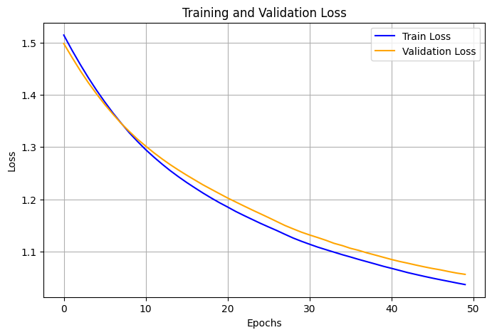

```python
import matplotlib.pyplot as plt

# Plot loss
plt.figure(figsize=(8, 5))
plt.plot(history.history['loss'], label='Train Loss', color='blue')
plt.plot(history.history['val_loss'], label='Validation Loss', color='orange')
plt.xlabel('Epochs')
plt.ylabel('Loss')
plt.title('Training and Validation Loss')
plt.legend()
plt.grid(True)
plt.show()
```

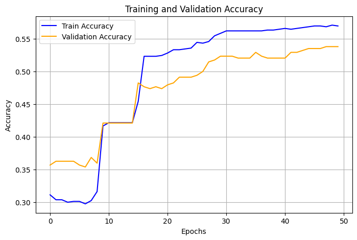

```python
# Plot accuracy
plt.figure(figsize=(8, 5))
plt.plot(history.history['accuracy'], label='Train Accuracy', color='blue')
plt.plot(history.history['val_accuracy'], label='Validation Accuracy', color='orange')
plt.xlabel('Epochs')
plt.ylabel('Accuracy')
plt.title('Training and Validation Accuracy')
plt.legend()
plt.grid(True)
plt.show()
```

### Q3 D. Design new architecture/update existing architecture in attempt to improve the performance of the model.

- To improve the performance of your model, we can try various strategies by changing activation or adding more hidden layers or batch normalization. Here trying to change activation:

```python
from keras.layers import LeakyReLU

# Define the model
model = Sequential()

model.add(Input(shape=(X_train.shape[1],)))
model.add(Dense(units=128))
model.add(LeakyReLU(negative_slope=0.01))  # Leaky ReLU with a small slope for negative inputs
model.add(Dense(units=64))
model.add(LeakyReLU(negative_slope=0.01))

model.add(Dense(units=y_train.shape[1], activation='softmax'))

# Compile the model
model.compile(optimizer='adam',
              loss='categorical_crossentropy',
              metrics=['accuracy'])
```

```python
#check metrics if that increased accuracy
# Train the model
history = model.fit(X_train, y_train, epochs=50, batch_size=32, validation_data=(X_test, y_test))

# Evaluate the model
loss, accuracy = model.evaluate(X_test, y_test)
print(f"Test Loss: {loss}")
print(f"Test Accuracy: {accuracy}")
```

```
25/25 ━━━━━━━━━━━━━━━━━━━━ 1s 9ms/step - accuracy: 0.3059 - loss: 1.4256 - val_accuracy: 0.5380 - val_loss: 1.1295
25/25 ━━━━━━━━━━━━━━━━━━━━ 0s 3ms/step - accuracy: 0.5535 - loss: 1.0599 - val_accuracy: 0.5643 - val_loss: 1.0439
25/25 ━━━━━━━━━━━━━━━━━━━━ 0s 3ms/step - accuracy: 0.5718 - loss: 1.0468 - val_accuracy: 0.5497 - val_loss: 1.0094
25/25 ━━━━━━━━━━━━━━━━━━━━ 0s 3ms/step - accuracy: 0.5892 - loss: 0.9414 - val_accuracy: 0.5380 - val_loss: 0.9874
25/25 ━━━━━━━━━━━━━━━━━━━━ 0s 3ms/step - accuracy: 0.5845 - loss: 0.9539 - val_accuracy: 0.5585 - val_loss: 0.9767
25/25 ━━━━━━━━━━━━━━━━━━━━ 0s 2ms/step - accuracy: 0.6014 - loss: 0.9248 - val_accuracy: 0.5673 - val_loss: 0.9738
25/25 ━━━━━━━━━━━━━━━━━━━━ 0s 2ms/step - accuracy: 0.6349 - loss: 0.8709 - val_accuracy: 0.5614 - val_loss: 0.9582
25/25 ━━━━━━━━━━━━━━━━━━━━ 0s 2ms/step - accuracy: 0.6239 - loss: 0.8823 - val_accuracy: 0.5526 - val_loss: 0.9598
25/25 ━━━━━━━━━━━━━━━━━━━━ 0s 2ms/step - accuracy: 0.6560 - loss: 0.8396 - val_accuracy: 0.5731 - val_loss: 0.9607
25/25 ━━━━━━━━━━━━━━━━━━━━ 0s 2ms/step - accuracy: 0.6478 - loss: 0.8351 - val_accuracy: 0.5526 - val_loss: 0.9648
25/25 ━━━━━━━━━━━━━━━━━━━━ 0s 3ms/step - accuracy: 0.6630 - loss: 0.7976 - val_accuracy: 0.5497 - val_loss: 0.9588
25/25 ━━━━━━━━━━━━━━━━━━━━ 0s 3ms/step - accuracy: 0.6358 - loss: 0.8619 - val_accuracy: 0.5614 - val_loss: 0.9497
25/25 ━━━━━━━━━━━━━━━━━━━━ 0s 3ms/step - accuracy: 0.6675 - loss: 0.7976 - val_accuracy: 0.5760 - val_loss: 0.9700
25/25 ━━━━━━━━━━━━━━━━━━━━ 0s 3ms/step - accuracy: 0.6731 - loss: 0.7713 - val_accuracy: 0.5439 - val_loss: 0.9564
25/25 ━━━━━━━━━━━━━━━━━━━━ 0s 3ms/step - accuracy: 0.6777 - loss: 0.7812 - val_accuracy: 0.5643 - val_loss: 0.9595
25/25 ━━━━━━━━━━━━━━━━━━━━ 0s 3ms/step - accuracy: 0.6801 - loss: 0.7678 - val_accuracy: 0.5526 - val_loss: 0.9562
25/25 ━━━━━━━━━━━━━━━━━━━━ 0s 3ms/step - accuracy: 0.6853 - loss: 0.7935 - val_accuracy: 0.5789 - val_loss: 0.9660
25/25 ━━━━━━━━━━━━━━━━━━━━ 0s 3ms/step - accuracy: 0.6789 - loss: 0.7505 - val_accuracy: 0.5556 - val_loss: 0.9645
25/25 ━━━━━━━━━━━━━━━━━━━━ 0s 2ms/step - accuracy: 0.6662 - loss: 0.7454 - val_accuracy: 0.5614 - val_loss: 0.9602
25/25 ━━━━━━━━━━━━━━━━━━━━ 0s 3ms/step - accuracy: 0.6906 - loss: 0.7482 - val_accuracy: 0.5643 - val_loss: 0.9613
25/25 ━━━━━━━━━━━━━━━━━━━━ 0s 2ms/step - accuracy: 0.6888 - loss: 0.7404 - val_accuracy: 0.5526 - val_loss: 0.9770
25/25 ━━━━━━━━━━━━━━━━━━━━ 0s 2ms/step - accuracy: 0.6962 - loss: 0.7077 - val_accuracy: 0.5614 - val_loss: 0.9748
25/25 ━━━━━━━━━━━━━━━━━━━━ 0s 2ms/step - accuracy: 0.6858 - loss: 0.7217 - val_accuracy: 0.5526 - val_loss: 0.9883
25/25 ━━━━━━━━━━━━━━━━━━━━ 0s 2ms/step - accuracy: 0.7063 - loss: 0.6957 - val_accuracy: 0.5731 - val_loss: 0.9833
25/25 ━━━━━━━━━━━━━━━━━━━━ 0s 2ms/step - accuracy: 0.7156 - loss: 0.6847 - val_accuracy: 0.5673 - val_loss: 0.9991
25/25 ━━━━━━━━━━━━━━━━━━━━ 0s 2ms/step - accuracy: 0.7099 - loss: 0.6726 - val_accuracy: 0.5760 - val_loss: 0.9905
25/25 ━━━━━━━━━━━━━━━━━━━━ 0s 2ms/step - accuracy: 0.7090 - loss: 0.6790 - val_accuracy: 0.5468 - val_loss: 1.0045
25/25 ━━━━━━━━━━━━━━━━━━━━ 0s 2ms/step - accuracy: 0.7298 - loss: 0.6590 - val_accuracy: 0.5497 - val_loss: 1.0028
25/25 ━━━━━━━━━━━━━━━━━━━━ 0s 3ms/step - accuracy: 0.7510 - loss: 0.6286 - val_accuracy: 0.5731 - val_loss: 1.0043
25/25 ━━━━━━━━━━━━━━━━━━━━ 0s 3ms/step - accuracy: 0.7197 - loss: 0.6668 - val_accuracy: 0.5614 - val_loss: 1.0121
25/25 ━━━━━━━━━━━━━━━━━━━━ 0s 2ms/step - accuracy: 0.7227 - loss: 0.6498 - val_accuracy: 0.5556 - val_loss: 1.0222
25/25 ━━━━━━━━━━━━━━━━━━━━ 0s 2ms/step - accuracy: 0.7421 - loss: 0.6205 - val_accuracy: 0.5497 - val_loss: 1.0162
25/25 ━━━━━━━━━━━━━━━━━━━━ 0s 2ms/step - accuracy: 0.7433 - loss: 0.6446 - val_accuracy: 0.5468 - val_loss: 1.0379
25/25 ━━━━━━━━━━━━━━━━━━━━ 0s 3ms/step - accuracy: 0.7380 - loss: 0.6215 - val_accuracy: 0.5643 - val_loss: 1.0278
25/25 ━━━━━━━━━━━━━━━━━━━━ 0s 3ms/step - accuracy: 0.7277 - loss: 0.6234 - val_accuracy: 0.5673 - val_loss: 1.0818
25/25 ━━━━━━━━━━━━━━━━━━━━ 0s 3ms/step - accuracy: 0.7446 - loss: 0.6332 - val_accuracy: 0.5497 - val_loss: 1.0407
25/25 ━━━━━━━━━━━━━━━━━━━━ 0s 6ms/step - accuracy: 0.7553 - loss: 0.5789 - val_accuracy: 0.5585 - val_loss: 1.0641
25/25 ━━━━━━━━━━━━━━━━━━━━ 0s 2ms/step - accuracy: 0.7454 - loss: 0.5932 - val_accuracy: 0.5468 - val_loss: 1.0439
25/25 ━━━━━━━━━━━━━━━━━━━━ 0s 2ms/step - accuracy: 0.7680 - loss: 0.5882 - val_accuracy: 0.5556 - val_loss: 1.1019
25/25 ━━━━━━━━━━━━━━━━━━━━ 0s 2ms/step - accuracy: 0.7487 - loss: 0.6149 - val_accuracy: 0.5614 - val_loss: 1.0780
25/25 ━━━━━━━━━━━━━━━━━━━━ 0s 3ms/step - accuracy: 0.7491 - loss: 0.5748 - val_accuracy: 0.5614 - val_loss: 1.0948
25/25 ━━━━━━━━━━━━━━━━━━━━ 0s 3ms/step - accuracy: 0.7530 - loss: 0.5598 - val_accuracy: 0.5643 - val_loss: 1.1041
25/25 ━━━━━━━━━━━━━━━━━━━━ 0s 3ms/step - accuracy: 0.7535 - loss: 0.5769 - val_accuracy: 0.5585 - val_loss: 1.0808
25/25 ━━━━━━━━━━━━━━━━━━━━ 0s 3ms/step - accuracy: 0.7771 - loss: 0.5674 - val_accuracy: 0.5585 - val_loss: 1.0847
25/25 ━━━━━━━━━━━━━━━━━━━━ 0s 3ms/step - accuracy: 0.7760 - loss: 0.5561 - val_accuracy: 0.5497 - val_loss: 1.1350
25/25 ━━━━━━━━━━━━━━━━━━━━ 0s 2ms/step - accuracy: 0.7487 - loss: 0.5761 - val_accuracy: 0.5614 - val_loss: 1.1586
25/25 ━━━━━━━━━━━━━━━━━━━━ 0s 3ms/step - accuracy: 0.7696 - loss: 0.5484 - val_accuracy: 0.5585 - val_loss: 1.1236
25/25 ━━━━━━━━━━━━━━━━━━━━ 0s 3ms/step - accuracy: 0.7997 - loss: 0.5392 - val_accuracy: 0.5585 - val_loss: 1.1364
25/25 ━━━━━━━━━━━━━━━━━━━━ 0s 3ms/step - accuracy: 0.7716 - loss: 0.5270 - val_accuracy: 0.5585 - val_loss: 1.1275
25/25 ━━━━━━━━━━━━━━━━━━━━ 0s 2ms/step - accuracy: 0.8121 - loss: 0.5333 - val_accuracy: 0.5526 - val_loss: 1.1455
11/11 ━━━━━━━━━━━━━━━━━━━━ 0s 877us/step - accuracy: 0.5439 - loss: 1.1689
Test Loss: 1.1454873085021973
Test Accuracy: 0.5526315569877625
```

```python
# Add the results to the DataFrame
test_df = {'Test Loss': [loss], 'Test Accuracy': [accuracy], 'Description': 'Changed Activation'}

results_df = pd.concat([results_df, pd.DataFrame(test_df)], ignore_index=True)
results_df
```

|  | Test Loss | Test Accuracy | Description |
| --- | --- | --- | --- |
| 0 | 1.056692 | 0.538012 | Baseline |
| 1 | 1.145487 | 0.552632 | Changed Activation |

- By changing activation, accuracy got increased

We can also try adding more Hidden Layers (Deepening the Network)

```python
#Adding more layers to deepen the network and add normalization
from keras.layers import BatchNormalization, Dropout

# Define the model
model = Sequential()

model.add(Input(shape=(X_train.shape[1],)))
model.add(Dense(units=128))
model.add(LeakyReLU(negative_slope=0.01))
model.add(BatchNormalization())  # Normalize activations for better convergence
model.add(Dropout(0.3))  # Apply dropout to prevent overfitting

model.add(Dense(units=64))
model.add(LeakyReLU(negative_slope=0.01))
model.add(BatchNormalization())
model.add(Dropout(0.3))

# Adding a third hidden layer to deepen the model
model.add(Dense(units=32))
model.add(LeakyReLU(negative_slope=0.01))
model.add(BatchNormalization())
model.add(Dropout(0.3))

model.add(Dense(units=y_train.shape[1], activation='softmax'))

# Compile the model
model.compile(optimizer='adam',
              loss='categorical_crossentropy',
              metrics=['accuracy'])
```

```python
#check metrics if that increased accuracy
# Train the model
history = model.fit(X_train, y_train, epochs=50, batch_size=32, validation_data=(X_test, y_test))

# Evaluate the model
loss, accuracy = model.evaluate(X_test, y_test)
print(f"Test Loss: {loss}")
print(f"Test Accuracy: {accuracy}")
```

```
25/25 ━━━━━━━━━━━━━━━━━━━━ 2s 11ms/step - accuracy: 0.2133 - loss: 2.2022 - val_accuracy: 0.4649 - val_loss: 1.4792
25/25 ━━━━━━━━━━━━━━━━━━━━ 0s 3ms/step - accuracy: 0.3222 - loss: 1.7660 - val_accuracy: 0.5117 - val_loss: 1.4111
25/25 ━━━━━━━━━━━━━━━━━━━━ 0s 3ms/step - accuracy: 0.4059 - loss: 1.5789 - val_accuracy: 0.5322 - val_loss: 1.3410
25/25 ━━━━━━━━━━━━━━━━━━━━ 0s 3ms/step - accuracy: 0.4322 - loss: 1.4075 - val_accuracy: 0.5497 - val_loss: 1.2670
25/25 ━━━━━━━━━━━━━━━━━━━━ 0s 3ms/step - accuracy: 0.4740 - loss: 1.4480 - val_accuracy: 0.5468 - val_loss: 1.2073
25/25 ━━━━━━━━━━━━━━━━━━━━ 0s 3ms/step - accuracy: 0.4858 - loss: 1.3493 - val_accuracy: 0.5673 - val_loss: 1.1555
25/25 ━━━━━━━━━━━━━━━━━━━━ 0s 3ms/step - accuracy: 0.5147 - loss: 1.2887 - val_accuracy: 0.5556 - val_loss: 1.1181
25/25 ━━━━━━━━━━━━━━━━━━━━ 0s 3ms/step - accuracy: 0.5353 - loss: 1.2076 - val_accuracy: 0.5731 - val_loss: 1.0954
25/25 ━━━━━━━━━━━━━━━━━━━━ 0s 3ms/step - accuracy: 0.5562 - loss: 1.1876 - val_accuracy: 0.5614 - val_loss: 1.0802
25/25 ━━━━━━━━━━━━━━━━━━━━ 0s 3ms/step - accuracy: 0.5727 - loss: 1.1970 - val_accuracy: 0.5614 - val_loss: 1.0614
25/25 ━━━━━━━━━━━━━━━━━━━━ 0s 3ms/step - accuracy: 0.5522 - loss: 1.1765 - val_accuracy: 0.5556 - val_loss: 1.0558
25/25 ━━━━━━━━━━━━━━━━━━━━ 0s 3ms/step - accuracy: 0.5336 - loss: 1.1377 - val_accuracy: 0.5731 - val_loss: 1.0417
25/25 ━━━━━━━━━━━━━━━━━━━━ 0s 4ms/step - accuracy: 0.5583 - loss: 1.1681 - val_accuracy: 0.5585 - val_loss: 1.0287
25/25 ━━━━━━━━━━━━━━━━━━━━ 0s 3ms/step - accuracy: 0.5709 - loss: 1.0767 - val_accuracy: 0.5702 - val_loss: 1.0231
25/25 ━━━━━━━━━━━━━━━━━━━━ 0s 3ms/step - accuracy: 0.5854 - loss: 1.0732 - val_accuracy: 0.5789 - val_loss: 1.0111
25/25 ━━━━━━━━━━━━━━━━━━━━ 0s 3ms/step - accuracy: 0.6309 - loss: 0.9848 - val_accuracy: 0.5702 - val_loss: 1.0062
25/25 ━━━━━━━━━━━━━━━━━━━━ 0s 3ms/step - accuracy: 0.6128 - loss: 0.9925 - val_accuracy: 0.5731 - val_loss: 0.9954
25/25 ━━━━━━━━━━━━━━━━━━━━ 0s 3ms/step - accuracy: 0.6058 - loss: 1.0375 - val_accuracy: 0.5760 - val_loss: 0.9885
25/25 ━━━━━━━━━━━━━━━━━━━━ 0s 3ms/step - accuracy: 0.6146 - loss: 0.9746 - val_accuracy: 0.5673 - val_loss: 0.9875
25/25 ━━━━━━━━━━━━━━━━━━━━ 0s 3ms/step - accuracy: 0.5999 - loss: 0.9882 - val_accuracy: 0.5731 - val_loss: 0.9825
25/25 ━━━━━━━━━━━━━━━━━━━━ 0s 3ms/step - accuracy: 0.5672 - loss: 1.0366 - val_accuracy: 0.5614 - val_loss: 0.9836
25/25 ━━━━━━━━━━━━━━━━━━━━ 0s 3ms/step - accuracy: 0.6053 - loss: 0.9921 - val_accuracy: 0.5585 - val_loss: 0.9855
25/25 ━━━━━━━━━━━━━━━━━━━━ 0s 3ms/step - accuracy: 0.6207 - loss: 0.9672 - val_accuracy: 0.5702 - val_loss: 0.9800
25/25 ━━━━━━━━━━━━━━━━━━━━ 0s 3ms/step - accuracy: 0.5860 - loss: 0.9716 - val_accuracy: 0.5673 - val_loss: 0.9800
25/25 ━━━━━━━━━━━━━━━━━━━━ 0s 3ms/step - accuracy: 0.6066 - loss: 0.9274 - val_accuracy: 0.5643 - val_loss: 0.9762
25/25 ━━━━━━━━━━━━━━━━━━━━ 0s 3ms/step - accuracy: 0.5860 - loss: 0.9802 - val_accuracy: 0.5702 - val_loss: 0.9775
25/25 ━━━━━━━━━━━━━━━━━━━━ 0s 3ms/step - accuracy: 0.6434 - loss: 0.9266 - val_accuracy: 0.5643 - val_loss: 0.9763
25/25 ━━━━━━━━━━━━━━━━━━━━ 0s 3ms/step - accuracy: 0.6270 - loss: 0.9685 - val_accuracy: 0.5731 - val_loss: 0.9704
25/25 ━━━━━━━━━━━━━━━━━━━━ 0s 3ms/step - accuracy: 0.6028 - loss: 0.9370 - val_accuracy: 0.5673 - val_loss: 0.9706
25/25 ━━━━━━━━━━━━━━━━━━━━ 0s 3ms/step - accuracy: 0.6177 - loss: 0.9161 - val_accuracy: 0.5731 - val_loss: 0.9624
25/25 ━━━━━━━━━━━━━━━━━━━━ 0s 3ms/step - accuracy: 0.6077 - loss: 0.9143 - val_accuracy: 0.5673 - val_loss: 0.9648
25/25 ━━━━━━━━━━━━━━━━━━━━ 0s 3ms/step - accuracy: 0.6243 - loss: 0.8994 - val_accuracy: 0.5819 - val_loss: 0.9643
25/25 ━━━━━━━━━━━━━━━━━━━━ 0s 3ms/step - accuracy: 0.6163 - loss: 0.9164 - val_accuracy: 0.5702 - val_loss: 0.9653
25/25 ━━━━━━━━━━━━━━━━━━━━ 0s 3ms/step - accuracy: 0.6021 - loss: 0.8891 - val_accuracy: 0.5760 - val_loss: 0.9660
25/25 ━━━━━━━━━━━━━━━━━━━━ 0s 3ms/step - accuracy: 0.6087 - loss: 0.9513 - val_accuracy: 0.5819 - val_loss: 0.9611
25/25 ━━━━━━━━━━━━━━━━━━━━ 0s 3ms/step - accuracy: 0.6325 - loss: 0.8568 - val_accuracy: 0.5848 - val_loss: 0.9597
25/25 ━━━━━━━━━━━━━━━━━━━━ 0s 3ms/step - accuracy: 0.6159 - loss: 0.8918 - val_accuracy: 0.5819 - val_loss: 0.9605
25/25 ━━━━━━━━━━━━━━━━━━━━ 0s 3ms/step - accuracy: 0.5896 - loss: 0.9622 - val_accuracy: 0.5789 - val_loss: 0.9612
25/25 ━━━━━━━━━━━━━━━━━━━━ 0s 3ms/step - accuracy: 0.6251 - loss: 0.8830 - val_accuracy: 0.5789 - val_loss: 0.9654
25/25 ━━━━━━━━━━━━━━━━━━━━ 0s 3ms/step - accuracy: 0.6192 - loss: 0.8702 - val_accuracy: 0.5789 - val_loss: 0.9646
25/25 ━━━━━━━━━━━━━━━━━━━━ 0s 3ms/step - accuracy: 0.6013 - loss: 0.9141 - val_accuracy: 0.5819 - val_loss: 0.9620
25/25 ━━━━━━━━━━━━━━━━━━━━ 0s 3ms/step - accuracy: 0.6381 - loss: 0.8493 - val_accuracy: 0.5731 - val_loss: 0.9635
25/25 ━━━━━━━━━━━━━━━━━━━━ 0s 3ms/step - accuracy: 0.6000 - loss: 0.8641 - val_accuracy: 0.5702 - val_loss: 0.9647
25/25 ━━━━━━━━━━━━━━━━━━━━ 0s 3ms/step - accuracy: 0.6229 - loss: 0.8536 - val_accuracy: 0.5760 - val_loss: 0.9614
25/25 ━━━━━━━━━━━━━━━━━━━━ 0s 3ms/step - accuracy: 0.6102 - loss: 0.8676 - val_accuracy: 0.5731 - val_loss: 0.9595
25/25 ━━━━━━━━━━━━━━━━━━━━ 0s 3ms/step - accuracy: 0.6305 - loss: 0.8696 - val_accuracy: 0.5760 - val_loss: 0.9635
25/25 ━━━━━━━━━━━━━━━━━━━━ 0s 4ms/step - accuracy: 0.6359 - loss: 0.8520 - val_accuracy: 0.5731 - val_loss: 0.9614
25/25 ━━━━━━━━━━━━━━━━━━━━ 0s 3ms/step - accuracy: 0.6325 - loss: 0.8811 - val_accuracy: 0.5556 - val_loss: 0.9617
25/25 ━━━━━━━━━━━━━━━━━━━━ 0s 3ms/step - accuracy: 0.6431 - loss: 0.8506 - val_accuracy: 0.5643 - val_loss: 0.9633
25/25 ━━━━━━━━━━━━━━━━━━━━ 0s 3ms/step - accuracy: 0.6566 - loss: 0.8229 - val_accuracy: 0.5731 - val_loss: 0.9662
11/11 ━━━━━━━━━━━━━━━━━━━━ 0s 1ms/step - accuracy: 0.5822 - loss: 0.9783
Test Loss: 0.966153085231781
Test Accuracy: 0.5730994343757629
```

```python
# Add the results to the DataFrame
test_df = {'Test Loss': [loss], 'Test Accuracy': [accuracy], 'Description': 'Added more layers and batch normalization'}

results_df = pd.concat([results_df, pd.DataFrame(test_df)], ignore_index=True)
results_df
```

|  | Test Loss | Test Accuracy | Description |
| --- | --- | --- | --- |
| 0 | 1.056692 | 0.538012 | Baseline |
| 1 | 1.145487 | 0.552632 | Changed Activation |
| 2 | 0.966153 | 0.573099 | Added more layers and batch normalization |